# NotesTP2

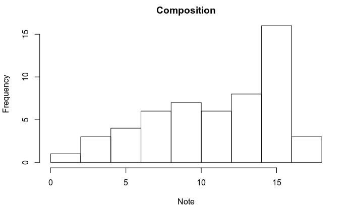

```r
library(MASS)
hist(painters$Composition, main = "Composition", xlab = "Note")
```

Calcul de toutes les moyennes

```r
(moyennes=(painters$Composition+painters$Drawing+painters$Colour+painters$Expression)/4)
```

```
 [1]  9.25 12.25 11.00 11.25  5.75 12.25  9.25 11.00  7.50 16.25  9.75 11.00  9.25 11.50 11.50 10.00 11.25 12.00  7.00 10.00
[21]  8.00 13.75  7.75  6.00  9.75  8.25 10.25  6.75 11.00 12.25 12.75 11.00 11.00  7.00 13.25 14.50 10.50 10.50 14.50  9.00
[41] 12.00  7.75  6.00 10.25 10.00 11.75 12.50 16.25 11.50 13.75  7.50 14.00 12.25 13.25
```

ou bien

```r
(moyennes=(painters[,1]+painters[,2]+painters[,3]+painters[,4])/4)
```

```
 [1]  9.25 12.25 11.00 11.25  5.75 12.25  9.25 11.00  7.50 16.25  9.75 11.00  9.25 11.50 11.50 10.00 11.25 12.00  7.00 10.00
[21]  8.00 13.75  7.75  6.00  9.75  8.25 10.25  6.75 11.00 12.25 12.75 11.00 11.00  7.00 13.25 14.50 10.50 10.50 14.50  9.00
[41] 12.00  7.75  6.00 10.25 10.00 11.75 12.50 16.25 11.50 13.75  7.50 14.00 12.25 13.25
```

variance PAS corrigé

```r
var(moyennes)*(length(moyennes)-1)/length(moyennes)
```

```
[1] 6.171982
```

et ec type PAS corrigé

```r
sd(moyennes)*sqrt((length(moyennes)-1)/length(moyennes))
```

```
[1] 2.484347
```

LES LOIS

— la loi uniforme : unif ; — la loi de Poisson : pois ; — la loi exponentielle : exp ; — la loi binomiale : binom ; — la loi normale : norm ; — la loi de Student : t ; — la loi du χ 2 : chisq ; — la loi de Fisher : f. Pour chacune de ces lois, il est possible d’accéder à la fonction de densité avec d, à la fonction de répartition avec p, aux fractiles avec q à un générateur de nombre aléatoire avec r.

```r
x=c(1,2,3,4,5)
(for (i in x){
  print(dunif(x = i,min = 2,max = 4))
})
```

```
[1] 0
[1] 0.5
[1] 0.5
[1] 0.5
[1] 0
NULL
```

ou bien

```r
dunif(x,min=2,max=4)
```

```
[1] 0.0 0.5 0.5 0.5 0.0
```

```r
punif(x,min=2,max = 4)
```

```
[1] 0.0 0.0 0.5 1.0 1.0
```

Question 6 1. une variable normale centrée-réduite est supérieure à 3 ;

```r
(1-pnorm(3,mean = 0, sd= 1))
```

```
[1] 0.001349898
```

2. une variable normale d’espérance 35 et d’écart-type 6 est inférieure à 42 ;

```r
pnorm(42,mean = 35,sd=6)
```

```
[1] 0.8783275
```

3. une variable normale d’espérance 35 et d’écart-type 6 est comprise entre 40 et 50 ;

```r
mu=35
sigma=6
(pnorm(50,mean = mu,sd=sigma)-pnorm(40,mean = mu,sd=sigma))
```

```
[1] 0.1961187
```

4. obtenir n − 1 faces sur n lancers d’une pièce de monnaie équilibrée, avec n = 5, 10, 30 ; C’est dans ce genre de loi discrete qu’on utilise d

```r
n=c(5,10,30)
dbinom(n-1,n,prob = 0.5)
```

```
[1] 1.562500e-01 9.765625e-03 2.793968e-08
```

5. obtenir strictement plus de 14 faces sur 20 lancers d’une pièce de monnaie équilibrée ;

```r
1-pbinom(14,size=20,prob = 0.5)
```

```
[1] 0.02069473
```

6. obtenir entre 10 et 15 faces sur 20 lancers d’une pièce de monnaie équilibrée.

```r
sum(dbinom((10:15),size = 20,prob = 0.5))
```

```
[1] 0.5821896
```

Question 7 Calcul de fractiles

```r
alpha <- c(0.05, 0.1, 0.9)
qnorm(alpha,mean=0,sd=1)
```

```
[1] -1.644854 -1.281552  1.281552
```

```r
qchisq(alpha,df=10)#df = degree of freedom
```

```
[1]  3.940299  4.865182 15.987179
```

3. loi de Student à 5 degrés de liberté ;

```r
qt(alpha,df=5)
```

```
[1] -2.015048 -1.475884  1.475884
```

. loi de Fisher à 2 et 5 degrés de liberté.

```r
qf(alpha,df1=2,df2=5)
```

```
[1] 0.05182311 0.10761220 3.77971608
```

Faire sa porpre fonction de répartition

```r
dloi <- function(x, b) {
  a <- 2/b^2
  f <- a * x
  f[x < 0] <- 0
  f[x > b] <- 0
  return(f)
}
x=c(-1, 0, 1, 2, 3, 4, 5)
dloi(-1:5,3)
```

```
[1] 0.0000000 0.0000000 0.2222222 0.4444444 0.6666667 0.0000000 0.0000000
```

faire une courbe pour dloi

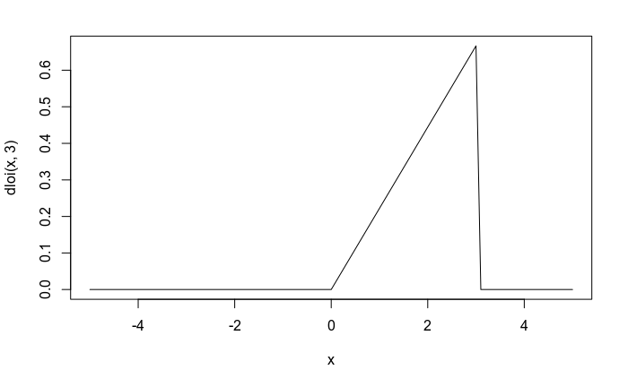

```r
curve(dloi(x,3),from = -5, to= 5)
```

coder ploi

```r
ploi <- function(x, b) {
  if (b <= 0)
    stop("on doit avoir b > 0")
  F <- x^2/b^2
  F[x < 0] <- 0
  F[x >= b] <- 1
  return(F)
}
#curve(ploi(x,3),from = -5, to= 5)
```

q

```r
qloi <- function(alpha, b) {
  fa <- b * sqrt(alpha)
  fa[alpha == 0] <- 0
  fa[alpha == 1] <- b
  return(fa)
}
#curve(qloi(x, 3), from = 0, to = 1)
```

r

```r
rloi <- function(n, b) {
u <- runif(n)
x <- qloi(u, b)
return(x)
}
```